# a_b_testing

### Investigation of A/B test data

Scenario:

- Scenario here is that fresh text has been tried in Latam countries rather than just using the Spanish text, so they are in more vernacular style
- The aim of this analysis on the test data is to see if this improved conversion or not

Makes use of:

- T-test for comparison of the two sample means of the test and control groups
- pymc3 for MCMC generation of posterior distributions of conversion rates for test and control groups

**Key conclusions**:

- Uruguay and Argentina are highly over-represented in the test
- Further, Uruguay and Argentina have lower conversion rates and so through this over-representation have a disproportionate effect on the overall conversion rate in the test
- Once this is accounted for, for instance by just looking within countries, the difference in conversion rates is not statistically significant, and so there is insignificant evidence to conclude that the test has resulted in a change in conversion rate
- To be sure, ideally would ask for the test to be re-run, with each country having very similar proportions within the test and control groups
- The test has only been carried out over 5 days -- ideally a longer period would be used e.g. 2 weeks

```python
import pandas as pd
import graphviz
import matplotlib.pyplot as plt
import pymc3 as pm

from scipy import stats
from datetime import date
from sklearn.tree import DecisionTreeClassifier
from sklearn.tree import export_graphviz

%config InlineBackend.figure_format = 'retina'
```

```python
# load
df_test = pd.read_csv('./data/test_table.csv')
df_user = pd.read_csv('./data/user_table.csv')
```

```python
df_test.head()
```

|  | user_id | date | source | device | browser_language | ads_channel | browser | conversion | test |
| --- | --- | --- | --- | --- | --- | --- | --- | --- | --- |
| 0 | 315281 | 2015-12-03 | Direct | Web | ES | NaN | IE | 1 | 0 |
| 1 | 497851 | 2015-12-04 | Ads | Web | ES | Google | IE | 0 | 1 |
| 2 | 848402 | 2015-12-04 | Ads | Web | ES | Facebook | Chrome | 0 | 0 |
| 3 | 290051 | 2015-12-03 | Ads | Mobile | Other | Facebook | Android_App | 0 | 1 |
| 4 | 548435 | 2015-11-30 | Ads | Web | ES | Google | FireFox | 0 | 1 |

```python
df_user.head()
```

|  | user_id | sex | age | country |
| --- | --- | --- | --- | --- |
| 0 | 765821 | M | 20 | Mexico |
| 1 | 343561 | F | 27 | Nicaragua |
| 2 | 118744 | M | 23 | Colombia |
| 3 | 987753 | F | 27 | Venezuela |
| 4 | 554597 | F | 20 | Spain |

```python
# check for duplicates, check to see if the same lengths
print('Duplicates', df_test.user_id.duplicated().sum(), df_user.user_id.duplicated().sum())
```

```
Duplicates 0 0
```

```python
# Some missing
print('Shapes', df_test.shape, df_user.shape)
print('len difference', len(df_test)-len(df_user))
```

```
Shapes (453321, 9) (452867, 4)
len difference 454
```

```python
# Inner join
df = df_user.set_index('user_id', drop=True).join(df_test.set_index('user_id', drop=True))
# Check dtypes
df.dtypes
```

```
sex                 object
age                  int64
country             object
date                object
source              object
device              object
browser_language    object
ads_channel         object
browser             object
conversion           int64
test                 int64
dtype: object
```

```python
# Convert datetime
df['date'] = df.date.map(pd.to_datetime)
df.dtypes
```

```
sex                         object
age                          int64
country                     object
date                datetime64[ns]
source                      object
device                      object
browser_language            object
ads_channel                 object
browser                     object
conversion                   int64
test                         int64
dtype: object
```

```python
df.head()
```

| user_id | sex | age | country | date | source | device | browser_language | ads_channel | browser | conversion | test |
| --- | --- | --- | --- | --- | --- | --- | --- | --- | --- | --- | --- |
| 765821 | M | 20 | Mexico | 2015-12-02 | Ads | Mobile | ES | Yahoo | Android_App | 0 | 1 |
| 343561 | F | 27 | Nicaragua | 2015-12-04 | Ads | Web | ES | Facebook | Safari | 0 | 0 |
| 118744 | M | 23 | Colombia | 2015-11-30 | Ads | Mobile | ES | Facebook | Android_App | 0 | 1 |
| 987753 | F | 27 | Venezuela | 2015-12-04 | SEO | Web | ES | NaN | IE | 0 | 1 |
| 554597 | F | 20 | Spain | 2015-12-04 | Direct | Web | ES | NaN | Chrome | 0 | 0 |

```python
df.describe()
```

|  | age | conversion | test |
| --- | --- | --- | --- |
| count | 452867.000000 | 452867.000000 | 452867.000000 |
| mean | 27.130740 | 0.049560 | 0.476462 |
| std | 6.776678 | 0.217034 | 0.499446 |
| min | 18.000000 | 0.000000 | 0.000000 |
| 25% | 22.000000 | 0.000000 | 0.000000 |
| 50% | 26.000000 | 0.000000 | 0.000000 |
| 75% | 31.000000 | 0.000000 | 1.000000 |
| max | 70.000000 | 1.000000 | 1.000000 |

```python
# Let's look at conversion rates for those not in tests
df.query('test == 0').groupby('country').mean().sort_values('conversion', ascending=False)
```

| country | age | conversion | test |
| --- | --- | --- | --- |
| Spain | 27.150805 | 0.079719 | 0.0 |
| El Salvador | 27.074489 | 0.053554 | 0.0 |
| Nicaragua | 27.316467 | 0.052647 | 0.0 |
| Costa Rica | 27.222556 | 0.052256 | 0.0 |
| Colombia | 27.178455 | 0.052089 | 0.0 |
| Honduras | 27.151112 | 0.050906 | 0.0 |
| Guatemala | 27.126738 | 0.050643 | 0.0 |
| Venezuela | 27.099758 | 0.050344 | 0.0 |
| Peru | 27.100539 | 0.049914 | 0.0 |
| Mexico | 27.140603 | 0.049495 | 0.0 |
| Bolivia | 27.196937 | 0.049369 | 0.0 |
| Ecuador | 27.110627 | 0.049154 | 0.0 |
| Paraguay | 27.127397 | 0.048493 | 0.0 |
| Chile | 27.188268 | 0.048107 | 0.0 |
| Panama | 27.099186 | 0.046796 | 0.0 |
| Argentina | 27.124198 | 0.015071 | 0.0 |
| Uruguay | 27.243373 | 0.012048 | 0.0 |

```python
# As we are going to compare test and control, makes sense to exclude Spain as not in both groups
df = df.query('country != "Spain"')

# Overall conversion rate test vs control
t_ = df.groupby('test')['conversion'].mean()
print(t_)

# Delta
print(t_[1]/t_[0]-1)

# 10% decline seems like a lot
```

```
test
0    0.048292
1    0.043411
Name: conversion, dtype: float64
-0.1010653948161575
```

```python
# Is this difference statistically significant?
# null hypothesis that means are equal
# let's see what the p-values look like

print(
    stats.ttest_ind(
        df.loc[df.test == 1, 'conversion'], # Conversions in test
        df.loc[df.test == 0, 'conversion'], # Conversions in control
        equal_var=True # Assume equal population variance
    ),
    '\n',
    stats.ttest_ind(
        df.loc[df.test == 1, 'conversion'], # Conversions in test
        df.loc[df.test == 0, 'conversion'], # Conversions in control
        equal_var=False # Do not assume equal population variance
    )
)

# p-values are both very small so we can reject the null that the means are the same
# => the means are different
```

```
Ttest_indResult(statistic=-7.382252163053967, pvalue=1.5593292778816856e-13)
 Ttest_indResult(statistic=-7.353895203080277, pvalue=1.928917857779903e-13)
```

```python
# Let's check the randomisation worked properly by trying separate these out
# If truely randomised, model will do poor job
df_curr = df.copy(deep=True)

# We only have 5 days worth so we can easily dummify these
print(df_curr.date.value_counts())

# Stringify date as we will dummify
df_curr['date'] = df_curr.date.apply(date.strftime, args=['%b-%d'])
```

```
2015-12-04    124894
2015-12-03     88110
2015-12-01     62835
2015-11-30     62826
2015-12-02     62420
Name: date, dtype: int64
```

```python
# y = test; conversion is not relevent here
# the rest willb e dummified
df_dummies = pd.get_dummies(df_curr.drop(columns=['conversion']))

X = df_dummies.copy(deep=True)
y = X.pop('test')
model = DecisionTreeClassifier(class_weight='balanced', # automatically adjust weights to reflect class frequencies
                               min_impurity_decrease=0.001, # don't split for the sake of it
                               random_state=0) # reproducability
model.fit(X, y) # Fit our model

!rm tree.dot
export_graphviz(model, out_file="tree.dot", feature_names=X.columns, proportion=True, rotate=True)

# Below will work if graphviz installed
!dot -Tpng tree.dot -o tree.png
!file tree.png
```

```
tree.png: PNG image data, 720 x 233, 8-bit/color RGB, non-interlaced
```

### Decision tree from model ($y$ is test)

[figure not shown]

```python
# Argentina and Uruguay are both massively over-represented in the test

t_ = df_dummies.groupby('test')['country_Argentina', 'country_Uruguay'].mean()
print('Proportions in test and control groups')
print(t_)
print('\nRatio of test proportion to control proportion')
print(t_.loc[1]/t_.loc[0])
```

```
Proportions in test and control groups
      country_Argentina  country_Uruguay
test
0              0.050488         0.002239
1              0.173223         0.017236

Ratio of test proportion to control proportion
country_Argentina    3.430965
country_Uruguay      7.696268
dtype: float64
```

```python
# And they have the weakest conversion values overall, both within test and control groups

df_conv_by_country = pd.concat(
    [
        df.groupby('country')['conversion'].mean().rename('overall'),
        df[df.test == 1].groupby('country')['conversion'].mean().rename('test'),
        df[df.test == 0].groupby('country')['conversion'].mean().rename('control')
    ], axis=1).sort_values('overall')
df_conv_by_country
```

| country | overall | test | control |
| --- | --- | --- | --- |
| Uruguay | 0.012821 | 0.012907 | 0.012048 |
| Argentina | 0.013994 | 0.013725 | 0.015071 |
| Panama | 0.048089 | 0.049370 | 0.046796 |
| Bolivia | 0.048634 | 0.047901 | 0.049369 |
| Paraguay | 0.048863 | 0.049229 | 0.048493 |
| Ecuador | 0.049072 | 0.048988 | 0.049154 |
| Honduras | 0.049253 | 0.047540 | 0.050906 |
| Guatemala | 0.049653 | 0.048647 | 0.050643 |
| Venezuela | 0.049666 | 0.048978 | 0.050344 |
| Chile | 0.049704 | 0.051295 | 0.048107 |
| Peru | 0.050258 | 0.050604 | 0.049914 |
| Mexico | 0.050341 | 0.051186 | 0.049495 |
| El Salvador | 0.050765 | 0.047947 | 0.053554 |
| Colombia | 0.051332 | 0.050571 | 0.052089 |
| Nicaragua | 0.053399 | 0.054177 | 0.052647 |
| Costa Rica | 0.053494 | 0.054738 | 0.052256 |

```python
# Let's add in p-values too so we can see what those look like

t_ = df.groupby('country')['conversion'].agg(
[
    ('p-value', lambda x: stats.ttest_ind(
        x[df["test"] == 1],
        x[df["test"] == 0],
        equal_var=False).pvalue),
    ('overall', lambda x: x.mean()),
    ('test', lambda x: x[df["test"] == 1].mean()),
    ('control', lambda x: x[df["test"] == 0].mean()),
], axis=1).sort_values(by='overall')

t_
# p-values are all large when we split by country so we can not reject the null that the means are the same
# => the means are not statistically significantly different

# These large p-values tell us that the probability of obtaining these data with the null being correct
# is high
```

| country | p-value | overall | test | control |
| --- | --- | --- | --- | --- |
| Uruguay | 0.879764 | 0.012821 | 0.012907 | 0.012048 |
| Argentina | 0.335147 | 0.013994 | 0.013725 | 0.015071 |
| Panama | 0.705327 | 0.048089 | 0.049370 | 0.046796 |
| Bolivia | 0.718885 | 0.048634 | 0.047901 | 0.049369 |
| Paraguay | 0.883697 | 0.048863 | 0.049229 | 0.048493 |
| Ecuador | 0.961512 | 0.049072 | 0.048988 | 0.049154 |
| Honduras | 0.471463 | 0.049253 | 0.047540 | 0.050906 |
| Guatemala | 0.572107 | 0.049653 | 0.048647 | 0.050643 |
| Venezuela | 0.573702 | 0.049666 | 0.048978 | 0.050344 |
| Chile | 0.302848 | 0.049704 | 0.051295 | 0.048107 |
| Peru | 0.771953 | 0.050258 | 0.050604 | 0.049914 |
| Mexico | 0.165544 | 0.050341 | 0.051186 | 0.049495 |
| El Salvador | 0.248127 | 0.050765 | 0.047947 | 0.053554 |
| Colombia | 0.423719 | 0.051332 | 0.050571 | 0.052089 |
| Nicaragua | 0.780400 | 0.053399 | 0.054177 | 0.052647 |
| Costa Rica | 0.687876 | 0.053494 | 0.054738 | 0.052256 |

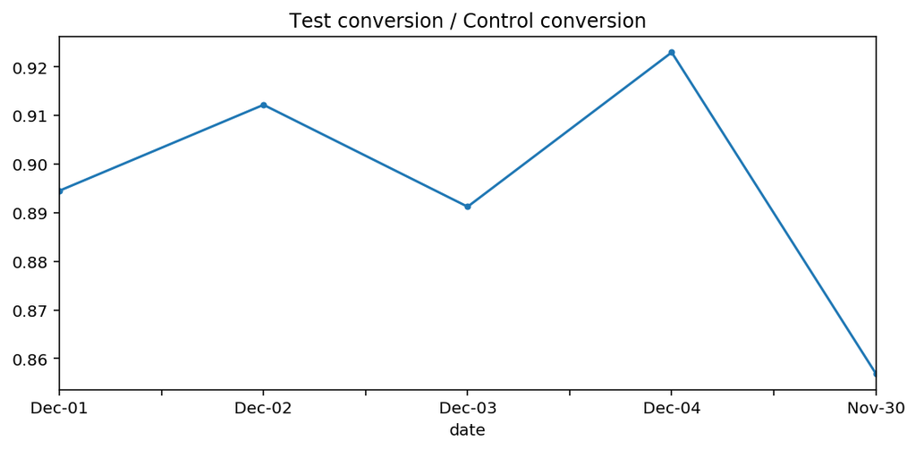

```python
# Check any obvious time effects

(
    df_curr[df_curr.test == 1].groupby('date')['conversion'].mean()
    /
    df_curr[df_curr.test == 0].groupby('date')['conversion'].mean()
).plot(title='Test conversion / Control conversion', style='.-', figsize=(9,4));
```

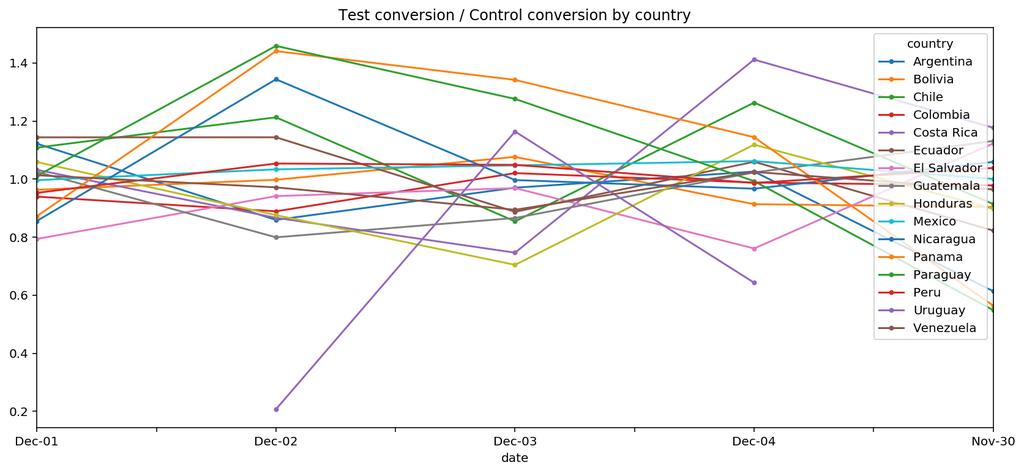

```python
# Check any obvious time effects by country

(
    df_curr[df_curr.test == 1].groupby(['country', 'date'])['conversion'].mean()
    /
    df_curr[df_curr.test == 0].groupby(['country', 'date'])['conversion'].mean()
).unstack().T.plot(title='Test conversion / Control conversion by country', style='.-', figsize=(14,6));
```

```python
# Let's say we also want to take a Baysian approach using MCMC to make doubly sure
# (in reality the sizes are large enough for this example that classical/frequentist is fine)
#
# We are interested in:
#
# P(True conversion rate | Data) ~~ P(Data | True conversion rate) · P(True conversion rate)
# i.e.
# posterior ~~ liklihood · prior

# Converstion values
test_vals = df.loc[df["test"] == 1, 'conversion'].values
cont_vals = df.loc[df["test"] == 0, 'conversion'].values

# Observed values
n = len(test_vals) + len(cont_vals)
obs_test = (test_vals == 1).sum()
obs_cont = (cont_vals == 1).sum()

with pm.Model() as model: # Context management
    # Define priors -- flat distributions for each
    prior_test = pm.Uniform('prior_test', 0, 1)
    prior_cont = pm.Uniform('prior_cont', 0, 1)

    # Define likelihood -- binomial likelihoods, feeding in the priors and observed data for each
    like_test = pm.Binomial('like_test', n=n, p=prior_test, observed=obs_test)
    like_cont = pm.Binomial('like_cont', n=n, p=prior_cont, observed=obs_cont)

    # Define metrics -- these are our differences between the two distibutions
    pm.Deterministic('difference', prior_test - prior_cont)
    pm.Deterministic('relation', (prior_test/prior_cont)-1)

    # Inference
    trace = pm.sample(draws=50000, step=pm.Metropolis(), start=pm.find_MAP(), progressbar=True)
```